# MEDBS datacall Report

Compiled on 08/01/2026, 14:37

# 1 Catch table

## 1.1 No replicated records in Catch data

Data included in the catch table were checked for the presence of duplicated records. The result of the check is here reported:

- No replicated records in Catch data

*Attention*: eventual duplicated records will be removed from catch data for the following analysis

## 1.2 Presence of disaggregated records

Data included in the catch table were checked for the presence of disaggregated records. The result of the check is here reported:

- No disaggregated records in Catch data

## 1.3 Check missing years in time series

Data where checked for the continuity of the time series, identifying the presence of missing years:

- No missing years in the Catch data time series for the selected combination: MUT - ITA - GSA 19
- The following years are missing in the Catch data time series (MTS - ITA - GSA 19): 2002, 2003

## 1.4 Catch data time series

### 1.4.1 GSA 19

#### 1.4.1.1 MUT

*Coverage of landing data for MUT in GSA 19*

| country | year | area | species | landings |
| --- | --- | --- | --- | --- |
| ITA | 2002 | GSA 19 | MUT | 2272.6749 |
| ITA | 2003 | GSA 19 | MUT | 2451.7673 |
| ITA | 2004 | GSA 19 | MUT | 950.9744 |
| ITA | 2005 | GSA 19 | MUT | 1113.6933 |
| ITA | 2006 | GSA 19 | MUT | 887.3784 |
| ITA | 2007 | GSA 19 | MUT | 541.1320 |
| ITA | 2008 | GSA 19 | MUT | 447.8137 |
| ITA | 2009 | GSA 19 | MUT | 529.4997 |
| ITA | 2010 | GSA 19 | MUT | 538.1157 |
| ITA | 2011 | GSA 19 | MUT | 588.3632 |
| ITA | 2012 | GSA 19 | MUT | 483.2749 |
| ITA | 2013 | GSA 19 | MUT | 274.4444 |
| ITA | 2014 | GSA 19 | MUT | 251.0272 |
| ITA | 2015 | GSA 19 | MUT | 303.6047 |
| ITA | 2016 | GSA 19 | MUT | 277.8580 |
| ITA | 2017 | GSA 19 | MUT | 294.9376 |
| ITA | 2018 | GSA 19 | MUT | 550.9929 |
| ITA | 2019 | GSA 19 | MUT | 460.6292 |
| ITA | 2020 | GSA 19 | MUT | 235.1400 |
| ITA | 2021 | GSA 19 | MUT | 218.9302 |
| ITA | 2022 | GSA 19 | MUT | 131.3130 |

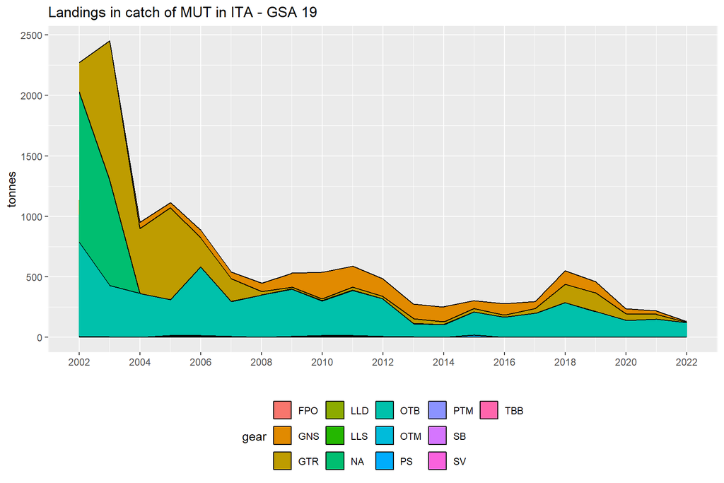

*Coverage of discard data for MUT in GSA 19*

| country | year | area | species | discards |
| --- | --- | --- | --- | --- |
| ITA | 2006 | GSA 19 | MUT | 0.00000 |
| ITA | 2009 | GSA 19 | MUT | 9.95927 |
| ITA | 2010 | GSA 19 | MUT | 0.00000 |
| ITA | 2011 | GSA 19 | MUT | 0.06355 |
| ITA | 2012 | GSA 19 | MUT | 3.29496 |
| ITA | 2013 | GSA 19 | MUT | 0.01674 |
| ITA | 2014 | GSA 19 | MUT | 1.45332 |
| ITA | 2015 | GSA 19 | MUT | 0.08444 |
| ITA | 2016 | GSA 19 | MUT | 0.12059 |
| ITA | 2017 | GSA 19 | MUT | 3.88479 |
| ITA | 2018 | GSA 19 | MUT | 1.12019 |
| ITA | 2019 | GSA 19 | MUT | 1.46657 |
| ITA | 2020 | GSA 19 | MUT | 0.08406 |
| ITA | 2021 | GSA 19 | MUT | 0.04916 |
| ITA | 2022 | GSA 19 | MUT | 0.00000 |

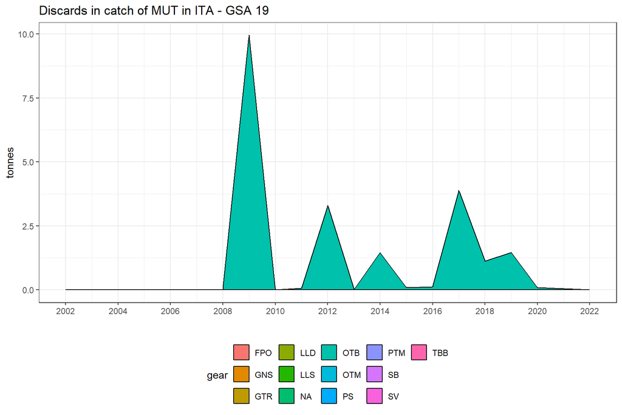

#### 1.4.1.2 MTS

*Coverage of landing data for MTS in GSA 19*

| country | year | area | species | landings |
| --- | --- | --- | --- | --- |
| ITA | 2004 | GSA 19 | MTS | 232.76548 |
| ITA | 2005 | GSA 19 | MTS | 152.57012 |
| ITA | 2006 | GSA 19 | MTS | 83.08653 |
| ITA | 2007 | GSA 19 | MTS | 135.07059 |
| ITA | 2008 | GSA 19 | MTS | 269.95876 |
| ITA | 2009 | GSA 19 | MTS | 289.47698 |
| ITA | 2010 | GSA 19 | MTS | 280.68824 |
| ITA | 2011 | GSA 19 | MTS | 305.15581 |
| ITA | 2012 | GSA 19 | MTS | 212.56817 |
| ITA | 2013 | GSA 19 | MTS | 124.42089 |
| ITA | 2014 | GSA 19 | MTS | 89.37593 |
| ITA | 2015 | GSA 19 | MTS | 118.26282 |
| ITA | 2016 | GSA 19 | MTS | 104.93366 |
| ITA | 2017 | GSA 19 | MTS | 82.38198 |
| ITA | 2018 | GSA 19 | MTS | 99.46777 |
| ITA | 2019 | GSA 19 | MTS | 97.73426 |
| ITA | 2020 | GSA 19 | MTS | 69.43070 |
| ITA | 2021 | GSA 19 | MTS | 107.58960 |
| ITA | 2022 | GSA 19 | MTS | 96.56000 |

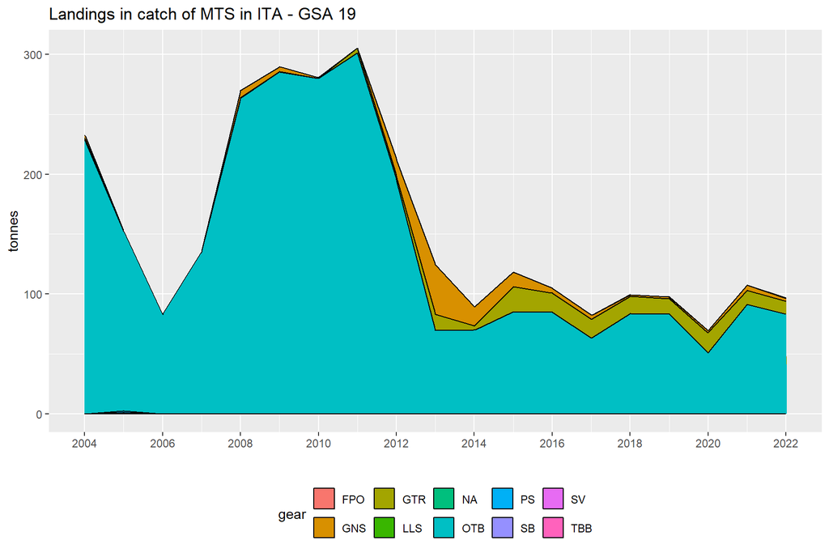

*Coverage of discard data for MTS in GSA 19*

| country | year | area | species | discards |
| --- | --- | --- | --- | --- |
| ITA | 2009 | GSA 19 | MTS | 19.16050 |
| ITA | 2010 | GSA 19 | MTS | 10.98028 |
| ITA | 2011 | GSA 19 | MTS | 9.85346 |
| ITA | 2012 | GSA 19 | MTS | 1.79010 |
| ITA | 2013 | GSA 19 | MTS | 2.81523 |
| ITA | 2014 | GSA 19 | MTS | 2.08876 |
| ITA | 2015 | GSA 19 | MTS | 1.27939 |
| ITA | 2016 | GSA 19 | MTS | 2.42188 |
| ITA | 2017 | GSA 19 | MTS | 5.49012 |
| ITA | 2018 | GSA 19 | MTS | 0.47492 |
| ITA | 2019 | GSA 19 | MTS | 3.40496 |
| ITA | 2020 | GSA 19 | MTS | 0.03049 |
| ITA | 2021 | GSA 19 | MTS | 0.07447 |
| ITA | 2022 | GSA 19 | MTS | 0.80286 |

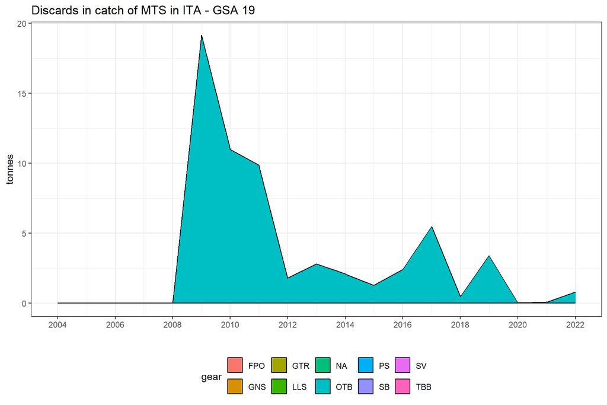

## 1.5 Check of Sum of Products (SOP)

Records for which the Sum Of Product (SOP) in weight differs in absolute terms more then 5% threshold chosen from the landings or discards volumes declared.

### 1.5.1 GSA 19

#### 1.5.1.1 MUT

*No critical values of SOP detected for MUT in GSA 19*

#### 1.5.1.2 MTS

*No critical values of SOP detected for MTS in GSA 19*

## 1.6 Check of length weight in landing and discard from Catch table

### 1.6.1 GSA 19

#### 1.6.1.1 MUT

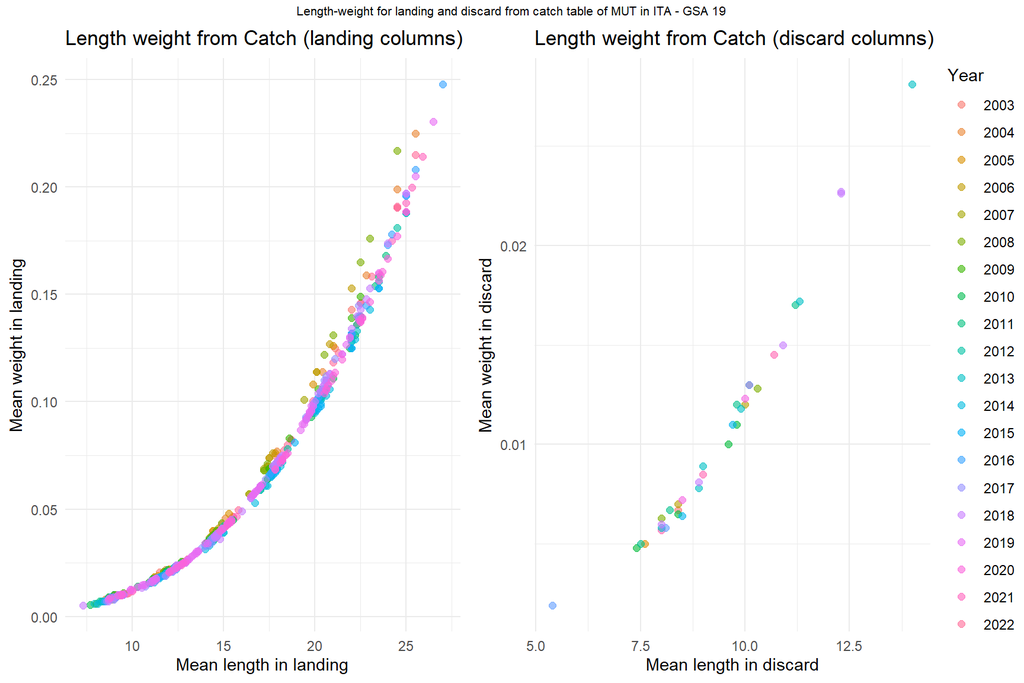

#### MTS

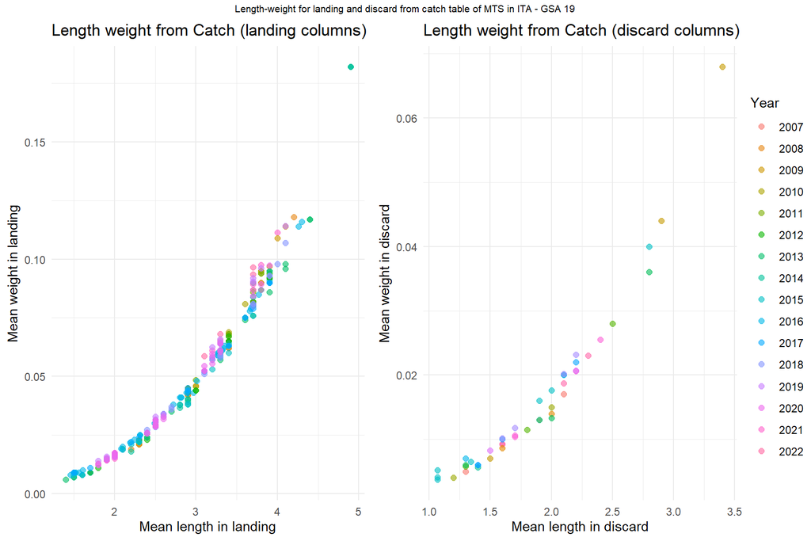

## 1.7 Check the numbers by age in landing and discard from Catch table

### 1.7.1 GSA 19

#### 1.7.1.1 MUT

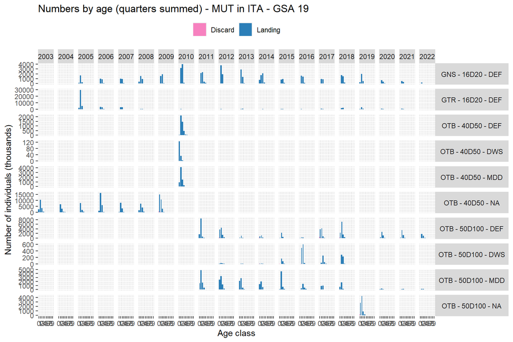

#### MTS

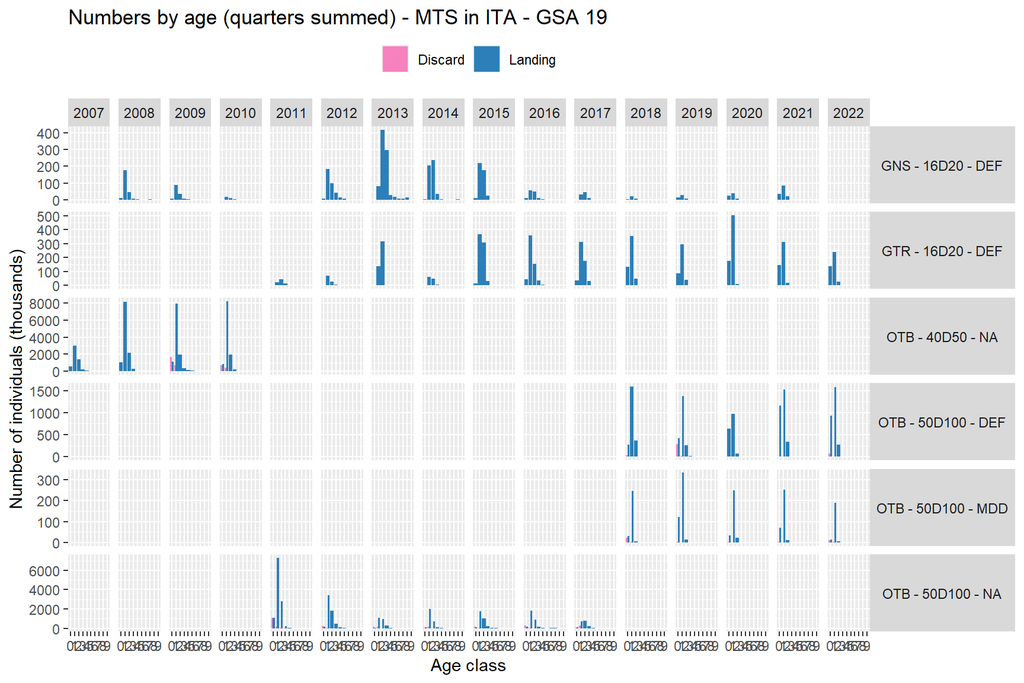

No Landing data available

No Discard data available

No growth parameters (GP) data available

No Maturity at Age (MA) data available

No Maturity at Length (ML) data available

No Sex Ratio at age (SRA) data available

No Sex Ratio at length (SRL) data available

# 2 Age-Length Keys (ALK) table

## 2.1 Presence of duplicated records

Data included in the ALK table were checked for the presence of duplicated records. The results of the check are here reported:

- No replicated records in ALK data

*Attention*: eventual duplicated records will be removed from ALK data for the following analysis

## 2.2 Plots of Age-Length Keys (ALK) data

### 2.2.1 GSA 19

#### 2.2.1.1 MUT

Plot of ALK for MUT - ITA - GSA 19 - Females

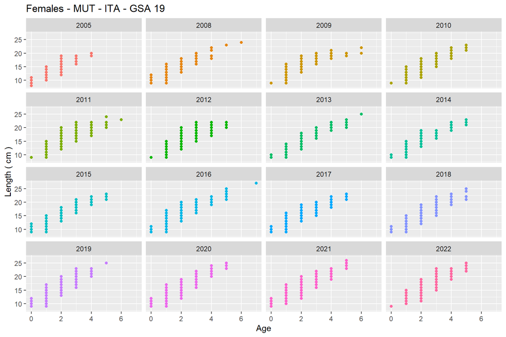

Plot of ALK for MUT - ITA - GSA 19 - Males

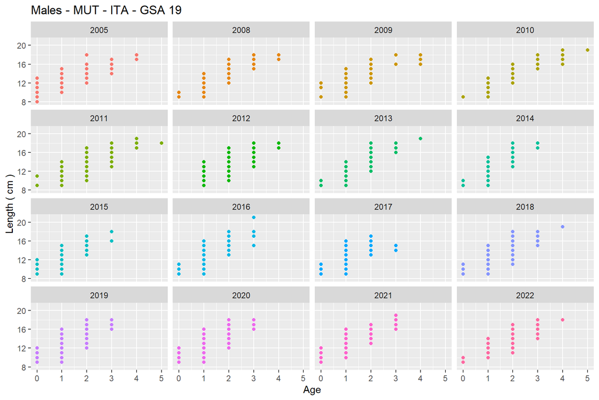

Plot of ALK for MUT - ITA - GSA 19 - Combined

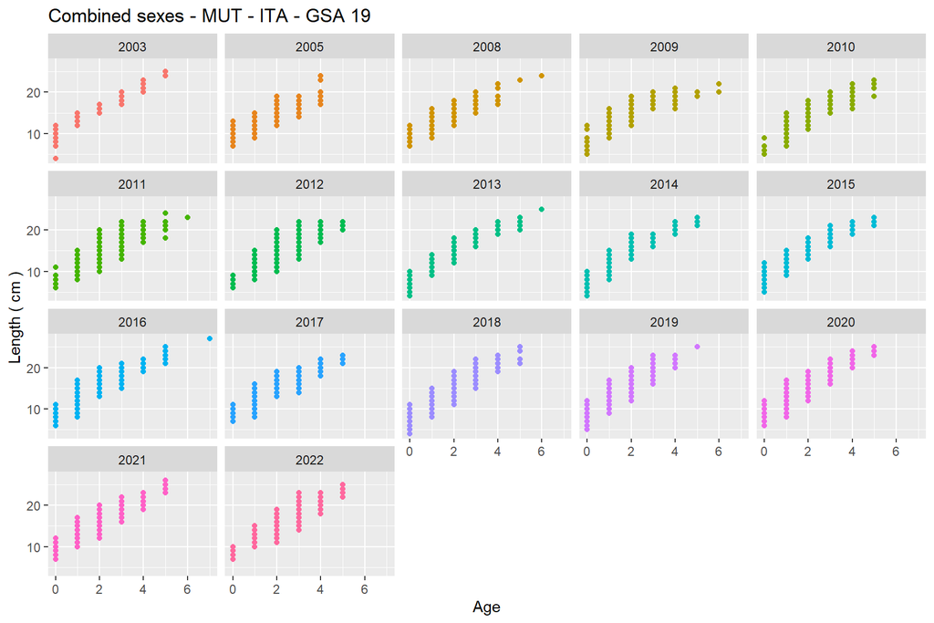

#### 2.2.1.2 MTS

## 2.3 Plots of mean length at age from the Age-Length Keys (ALK) data

### 2.3.1 GSA 19

#### 2.3.1.1 MUT

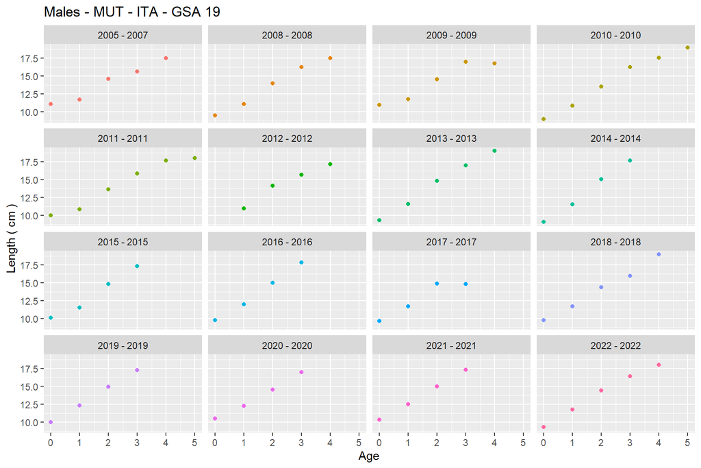

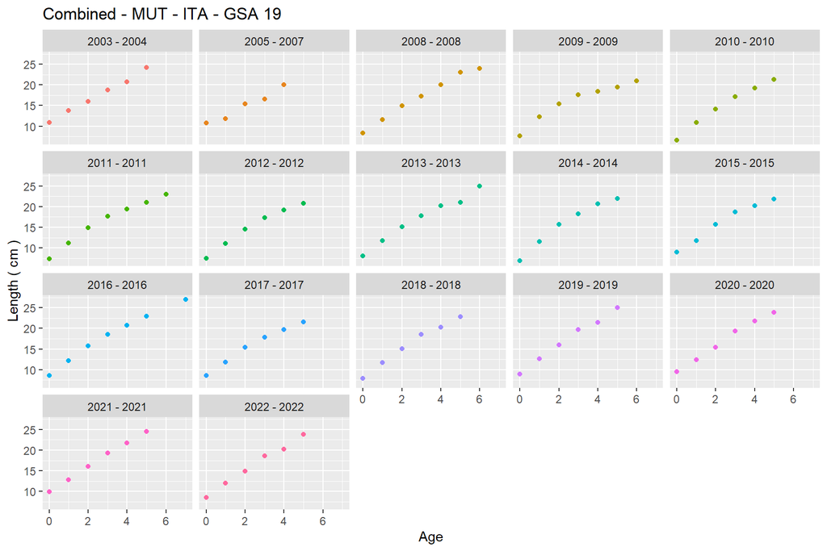

#### 2.3.1.2 MTS

- No ALK data are available for the selected combination: MTS - ITA - GSA 19.

## 2.4 Check if the total number of hard structures is consistent with the sum of numbers by age in the Age-Length Keys (ALK) data

### 2.4.1 GSA 19

#### 2.4.1.1 MUT

Records for which the total number of hard structures is not consistent with the sum of numbers by age from ALK for MUT - ITA - GSA 19 -

| START_YEAR | END_YEAR | SEX | AREA | TOTAL_NUMBER_OF_HARD_STRUCTURE_READ_BY_AGE | total_n | diff |
| --- | --- | --- | --- | --- | --- | --- |
| 2009 | 2009 | C | GSA 19 | 2 | 4 | -2 |
| 2009 | 2009 | F | GSA 19 | 2 | 4 | -2 |
| 2010 | 2010 | M | GSA 19 | 1 | 2 | -1 |
| 2011 | 2011 | F | GSA 19 | 1 | 2 | -1 |

#### 2.4.1.2 MTS

- No ALK data are available for the selected combination: MTS - ITA - GSA 19.